# JMSC 6116 Lecture 4: War of Discourse: ‘Wuhan coronavirus’ vs. ‘COVID-19’ in the Media

King-wa Fu

February 21, 2020

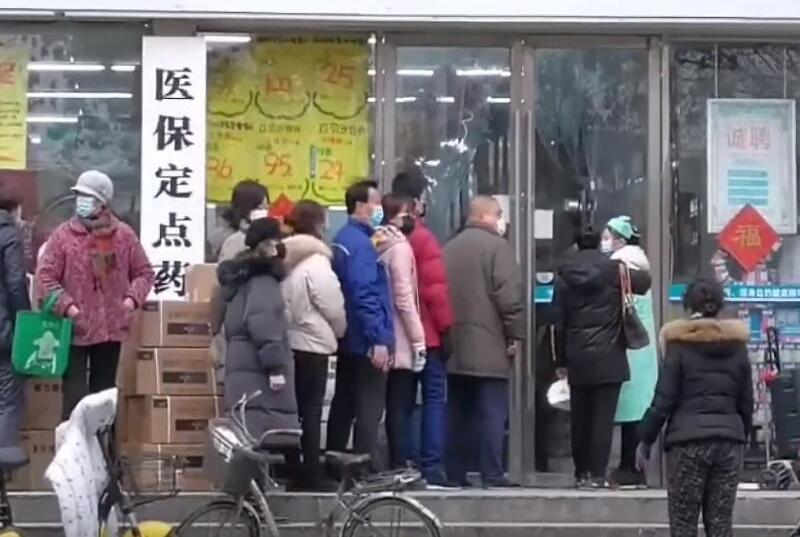

When the media reports the stories about the recent outbreak, which term, ‘Wuhan coronavirus’ or ‘COVID-19’, is more likely to be referred after WHO’s annouceement of the official name? Which publications do prefer to use each in the title?

“Require” the two packages.

```r
require(RJSONIO)
require(RCurl)
```

Following NewsAPI’s instruction (https://newsapi.org/docs/endpoints/everything), we setup the key and the search query ‘Wuhan coronavirus’.

Let’s get the first 100 articles and have a look at the data structure.

```r
date <- '2020-02-17'
search_q <- URLencode("'Wuhan coronavirus'")
url <- paste('https://newsapi.org/v2/everything?q=',search_q,'&from=',date,'&page=1&pageSize=100&apiKey=',api,sep="")
wuhan <- fromJSON(getURL(url))

str(wuhan$articles[[1]])
```

```
## List of 8
##  $ source     :List of 2
##   ..$ id  : NULL
##   ..$ name: chr "Gizmodo.com"
##  $ author     : chr "Matt Novak"
##  $ title      : chr "Chinese Media Declares Hospital Director Dead From COVID-19, Then Alive, Then Dead Again"
##  $ description: chr "Liu Zhiming, the 51-year-old director of Wuchang Hospital in Wuhan, China, died at 10:54 AM local time Tuesday "| __truncated__
##  $ url        : chr "https://gizmodo.com/chinese-media-declares-hospital-director-dead-from-covi-1841757263"
##  $ urlToImage : chr "https://i.kinja-img.com/gawker-media/image/upload/c_fill,f_auto,fl_progressive,g_center,h_675,pg_1,q_80,w_1200/"| __truncated__
##  $ publishedAt: chr "2020-02-18T12:30:00Z"
##  $ content    : chr "Liu Zhiming, the 51-year-old director of Wuchang Hospital in Wuhan, China, died at 10:54 AM local time Tuesday "| __truncated__
```

```r
wuhan$totalResults
```

```
## [1] 3178
```

We are interested in the articles. Let’s have a look.

```r
newsdata_df1 <- lapply(wuhan$articles,function(x){
    return(c(x[["source"]][["name"]],x[["author"]],x[["title"]],x[["publishedAt"]],x[["content"]]))
})

newsdata_df1 <- do.call(rbind.data.frame,newsdata_df1)
colnames(newsdata_df1) <- c("source","author","title","publishedAt","content")

newsdata_df1$source[1:10]  # First ten names
```

```
##  [1] Gizmodo.com BBC News    BBC News    Gizmodo.com Reuters     Gizmodo.com
##  [7] Cnet.com    Youtube.com BBC News    Reuters
## 37 Levels: ABC News Al Jazeera English BBC News ... Youtube.com
```

```r
newsdata_df1$title[1:10] # First ten titles
```

```
##  [1] Chinese Media Declares Hospital Director Dead From COVID-19, Then Alive, Then Dead Again
##  [2] The noted victims of the coronavirus
##  [3] Coronavirus: How a misleading map went global
##  [4] Global Death Toll from COVID-19 Surpasses 2,000, Though China Maintains Outbreak Slowing Down
##  [5] Factbox: Countries evacuating nationals from China coronavirus areas
##  [6] Why Are HIV Drugs Being Used to Treat the New Coronavirus?
##  [7] Chilling footage emerges of China's deserted streets in coronavirus epicenter - CNET
##  [8] 2020-02-19T10:20:50Z
##  [9] Coronavirus triggers boom in private jet inquiries
## [10] China's Hubei province reports 132 new coronavirus deaths on Feb. 18
## 93 Levels: 'Everything is a mess': Westerdam passengers in limbo again after passenger testing positive for coronavirus prompts countries to not let them 'fly through' ...
```

it’s time to use the command ‘aggregate’. First, let’s count for the first 100 ‘Wuhan coronavirus’ data 1) how many articles by newspaper; 2) number of titles mentioning ‘Wuhan coronavirus’; 3) number of mentions of ‘government’ in the content

```r
aggregate(title ~ source,newsdata_df1,length) # Count of each newspaper
```

```
##                source title
## 1            ABC News     2
## 2  Al Jazeera English     1
## 3            BBC News     5
## 4      Boingboing.net     4
## 5    Business Insider    14
## 6            Cnet.com     2
## 7                 CNN     1
## 8          Ctvnews.ca     1
## 9      Dailyforex.com     1
## 10         Dezeen.com     1
## 11      Ejinsight.com     1
## 12    Fastcompany.com     3
## 13     Fayerwayer.com     1
## 14        Gizmodo.com     3
```

[output cut: 23 more lines]

```r
aggregate(title ~ source,newsdata_df1,function(x){ # Count of number of title mention
  sum(grepl('Wuhan coronavirus',x, ignore.case = T))
})
```

```
##                source title
## 1            ABC News     0
## 2  Al Jazeera English     0
## 3            BBC News     0
## 4      Boingboing.net     0
## 5    Business Insider     3
## 6            Cnet.com     0
## 7                 CNN     0
## 8          Ctvnews.ca     0
## 9      Dailyforex.com     0
## 10         Dezeen.com     0
## 11      Ejinsight.com     0
## 12    Fastcompany.com     2
## 13     Fayerwayer.com     0
## 14        Gizmodo.com     0
```

[output cut: 23 more lines]

```r
aggregate(content ~ source,newsdata_df1,function(x){ # Count of number of title mentioning 'government'
  sum(grepl('government',x, ignore.case = T))
})
```

```
##                source content
## 1            ABC News       1
## 2  Al Jazeera English       0
## 3            BBC News       0
## 4      Boingboing.net       1
## 5    Business Insider       2
## 6            Cnet.com       0
## 7                 CNN       0
## 8          Ctvnews.ca       0
## 9      Dailyforex.com       0
## 10         Dezeen.com       0
## 11      Ejinsight.com       1
## 12    Fastcompany.com       0
## 13     Fayerwayer.com       0
## 14        Gizmodo.com       1
```

[output cut: 23 more lines]

Next, we try searching ‘COVID-19’ and check the total number of hits.

```r
search_q <- URLencode("'COVID-19'")
url <- paste('https://newsapi.org/v2/everything?q=',search_q,'&from=',date,'&page=1&pageSize=100&apiKey=',api,sep="")
covid19 <- fromJSON(getURL(url))

covid19$totalResults
```

```
## [1] 7509
```

```r
newsdata_df2 <- lapply(covid19$articles,function(x){
    return(c(x[["source"]][["name"]],x[["author"]],x[["title"]],x[["publishedAt"]],x[["content"]]))
})

newsdata_df2 <- do.call(rbind.data.frame,newsdata_df2)
colnames(newsdata_df2) <- c("source","author","title","publishedAt","content")
```

Again, let’s count for the first 100 ‘COVID-19’ data: 1) how many articles by each newspaper; 2) number of titles mentioning ‘COVID-19’; 3) number of mentions of ‘government’ in the content

```r
aggregate(title ~ source,newsdata_df2,length) # Count of each newspaper
```

```
##                source title
## 1            ABC News     5
## 2  Al Jazeera English     1
## 3  Androidcentral.com     1
## 4        Ars Technica     1
## 5            BBC News     2
## 6             Bbc.com     1
## 7    Business Insider     8
## 8                 CNN     2
## 9          Core77.com     1
## 10         Ctvnews.ca     3
## 11     Dailyforex.com     1
## 12      Ejinsight.com     1
## 13           Engadget     2
## 14    Fastcompany.com     2
```

[output cut: 32 more lines]

```r
aggregate(title ~ source,newsdata_df2,function(x){ # Count of number of title mention
  sum(grepl('COVID-19',x, ignore.case = T))
})
```

```
##                source title
## 1            ABC News     0
## 2  Al Jazeera English     1
## 3  Androidcentral.com     0
## 4        Ars Technica     0
## 5            BBC News     0
## 6             Bbc.com     0
## 7    Business Insider     0
## 8                 CNN     0
## 9          Core77.com     1
## 10         Ctvnews.ca     0
## 11     Dailyforex.com     0
## 12      Ejinsight.com     0
## 13           Engadget     0
## 14    Fastcompany.com     0
```

[output cut: 32 more lines]

```r
aggregate(content ~ source,newsdata_df2,function(x){ # Count of number of title mentioning 'government'
  sum(grepl('government',x))
})
```

```
##                source content
## 1            ABC News       2
## 2  Al Jazeera English       0
## 3  Androidcentral.com       0
## 4        Ars Technica       0
## 5            BBC News       0
## 6             Bbc.com       0
## 7    Business Insider       1
## 8                 CNN       0
## 9          Core77.com       0
## 10         Ctvnews.ca       0
## 11     Dailyforex.com       0
## 12      Ejinsight.com       0
## 13           Engadget       0
## 14    Fastcompany.com       0
```

[output cut: 32 more lines]

Why don’t we create a function to read a numebr of pages of data? A function called GetAllData is created.

```r
## Create a function to read all news stories

GetAllData <- function(ndata,sterm){
  max_page <- 10    # maximun pages of returned results
  npage <- ceiling(ndata$totalResults)  # Calcualte the total numebr of pages required
  npage <- ifelse(npage >= max_page,max_page,npage)
  output_data <- c()
  for (p in 1:npage){

    search_q <- URLencode(sterm)
    url <- paste('https://newsapi.org/v2/everything?q=',search_q,'&from=',date,'&page=',p,'&pageSize=100&apiKey=',api,sep="")
    res_df <- fromJSON(getURL(url))

    if (!is.atomic(res_df)){
      data_df <- lapply(res_df$articles,function(x){
        return(c(x[["source"]][["name"]],x[["author"]],x[["title"]],x[["publishedAt"]],x[["content"]]))
      })

      data_df <- do.call(rbind.data.frame,data_df)
      colnames(data_df) <- c("source","author","title","publishedAt","content")

      output_data <- rbind(output_data,data_df)
      Sys.sleep(15)
    }
  }
  return(output_data)
}
```

Ready to run. Rerun the aggregate command to get the numbers of articles by news source, and sorted by descending order of the counts.

```r
Allnewsdata1_df <- GetAllData(wuhan,'"Wuhan coronavirus"')
Allnewsdata2_df <- GetAllData(covid19,'"COVID-19"')

d1 <- aggregate(title ~ source,Allnewsdata1_df,function(x){ # Count of number of title mention
  sum(grepl('Wuhan coronavirus',x, ignore.case = T))
})

d2 <- aggregate(title ~ source,Allnewsdata2_df,function(x){ # Count of number of title mention
  sum(grepl('COVID-19',x, ignore.case = T))
})

d1[order(d1$title,decreasing=T),] # Display in descending order
```

```
##                     source title
## 6         Business Insider     4
## 12         Fastcompany.com     4
## 29         Naturalnews.com     4
## 45               Yahoo.com     3
## 2          Bizjournals.com     1
## 7   Businessinsider.com.au     1
## 21           Johnnyjet.com     1
## 28    Nationalinterest.org     1
## 1                  Aei.org     0
## 3           Boingboing.net     0
## 4           Breitbart News     0
## 5              Bruegel.org     0
## 8          Cinemablend.com     0
## 9                 Coed.com     0
```

[output cut: 32 more lines]

```r
d2[order(d2$title,decreasing=T),] # Display in descending order
```

```
##                source title
## 15     Fayerwayer.com     3
## 41               Time     3
## 18        Gizmodo.com     2
## 20      Globalnews.ca     2
## 37     Spiegel Online     2
## 2  Al Jazeera English     1
## 9          Core77.com     1
## 35          Scroll.in     1
## 40    Theatlantic.com     1
## 1            ABC News     0
## 3  Androidcentral.com     0
## 4        Ars Technica     0
## 5            BBC News     0
## 6             Bbc.com     0
```

[output cut: 32 more lines]